# Selecting the best fit model for ATAC-seq analyses

RSTR vs. LTBI, nucleosome free data

Kim Dill-McFarland, kadm@uw.edu

version November 10, 2022

# Setup

Load packages

```r
##Addtl tidy function
library(plyr)
# Data manipulation and figures
library(tidyverse)
  ## Multi-panel figures
  library(patchwork)
  ## Add P-values to ggplots
  library(ggpubr)
  ## kimma figures
  library(BIGpicture)

# Linear regression
library(limma)
library(kimma)

#Parallel computing
library(foreach)
library(doParallel)

#Print pretty tables to Rmd
library(knitr)
library(kableExtra)
  options(knitr.kable.NA = '')
```

Set seed

```r
set.seed(589)
```

# Load data

Load data from “ATAC-seq data clean-up”.

```r
load("data_ATACseq_clean/ATACseq_data.RData")

#Rename all to FULLIDNO
counts <- as.data.frame(voomQW.Nfree.abund.norm$E) %>%
  rownames_to_column() %>%
  pivot_longer(-rowname, names_to = "RS_SUB_ACCESSION_NO") %>%
  left_join(select(voomQW.Nfree.abund.norm$targets, RS_SUB_ACCESSION_NO, FULLIDNO)) %>%
  select(-RS_SUB_ACCESSION_NO) %>%
  arrange(FULLIDNO) %>%
  pivot_wider(names_from = FULLIDNO) %>%
  column_to_rownames()
kin.format <- kin %>%
  rownames_to_column() %>%
  pivot_longer(-rowname) %>%
  left_join(select(voomQW.Nfree.abund.norm$targets, RS_SUB_ACCESSION_NO, FULLIDNO),
            by = c("rowname"="RS_SUB_ACCESSION_NO")) %>%
  rename(rowname.new = FULLIDNO) %>%
  left_join(select(voomQW.Nfree.abund.norm$targets, RS_SUB_ACCESSION_NO, FULLIDNO),
            by = c("name"="RS_SUB_ACCESSION_NO")) %>%
  rename(name.new = FULLIDNO) %>%
  select(-rowname, -name) %>%
  arrange(name.new) %>%
  pivot_wider(names_from = name.new) %>%
  arrange(rowname.new) %>%
  column_to_rownames("rowname.new")

meta <- voomQW.Nfree.abund.norm$targets
```

# Selecting metadata of interest

## Genetic relatedness

A number of study participants are blood relatives. Thus, differential accessibility models may need to be corrected for relatedness. We explore 2 methods for this including 1) blocking samples by family groups or 2) including genetic kinship values (calculated from SNPs) as a random effect.

### Family blocks

Third degree relatedness includes great-grandparents, great grandchildren, great uncles/aunts, and first cousins. It corresponds to ~12.5% genetic identity.

3rd degree families with 2+ members

| Family size | Total families |
| --- | --- |
| 5 | 1 |
| 4 | 1 |
| 3 | 4 |
| 2 | 5 |

Second degree relatedness includes grandparents, grandchildren, uncles/aunts, nieces/nephews, and half-siblings. It corresponds to ~25% genetic identity.

2nd degree families with 2+ members

| Family size | Total families |
| --- | --- |
| 4 | 1 |
| 3 | 4 |
| 2 | 5 |

1st degree families with 2+ members

| Family size | Total families |
| --- | --- |
| 4 | 1 |
| 3 | 4 |
| 2 | 3 |

Here, we see that family blocks do not group in MDS.

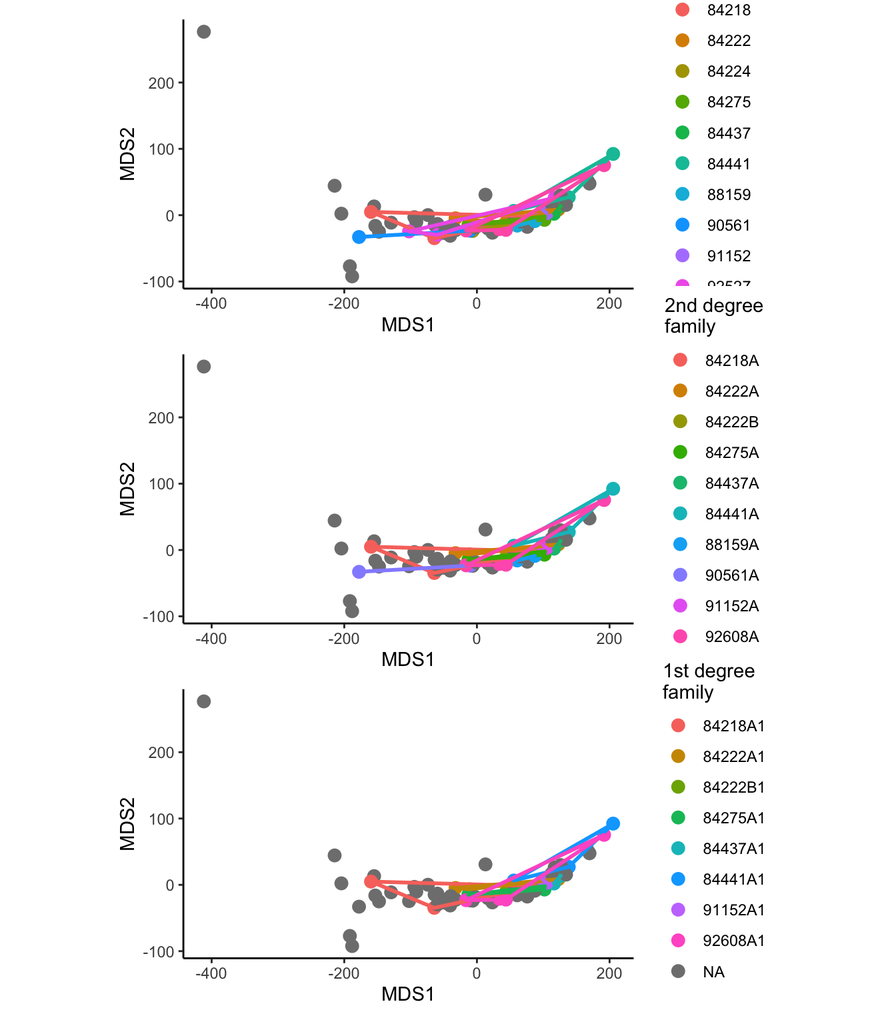

Furthermore, blocking by family groups does not improve model fit for the vast majority (> 94%) of peaks. See `scripts/ATAC.models.R` for running of `kmFit` models.

```
## Summary
```

```
##                          Best fit Metric Total genes Mean delta Stdev delta
## 1             lm_Sample_GroupRSTR    AIC       39922   4.168518    1.366991
## 2 lme_Sample_Group_(1 | family.1)    AIC        2433   2.560301    2.558690
```

```
## Summary
```

```
##                          Best fit Metric Total genes Mean delta Stdev delta
## 1             lm_Sample_GroupRSTR    AIC       40254   4.184551    1.341533
## 2 lme_Sample_Group_(1 | family.2)    AIC        2101   2.421617    2.395928
```

```
## Summary
```

```
##                          Best fit Metric Total genes Mean delta Stdev delta
## 1             lm_Sample_GroupRSTR    AIC       40451   4.289408    1.328320
## 2 lme_Sample_Group_(1 | family.3)    AIC        1904   2.459261    2.517144
```

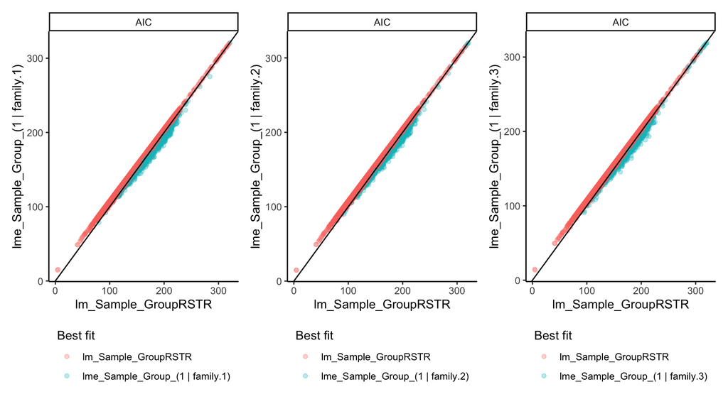

### Kinship matrix

Individuals were genotyped by Omni5 or MegaEx Chip, and pairwise kinship scores were calculated using PC-Relate in the Genesis package (Stein and Benchek). In the ATACseq data, 60 of 64 samples have kinship data.

See `scripts/ATAC.models.R` for running of `kmFit` models

Given this and kinship’s use in other data set analyses, kinship will be used in all further models.

```
## Summary
```

```
##                             Best fit Metric Total genes   Mean delta
## 1                lm_Sample_GroupRSTR    AIC       40375 4.080783e+00
## 2 lmerel_Sample_Group_(1 | FULLIDNO)    AIC        1980 1.508095e+00
## 3                lm_Sample_GroupRSTR  sigma        4148 2.461735e-16
## 4 lmerel_Sample_Group_(1 | FULLIDNO)  sigma       32953 4.134892e-01
## 5                               none  sigma        5254 0.000000e+00
##    Stdev delta
## 1 1.415776e+00
## 2 1.420211e+00
## 3 1.299818e-16
## 4 3.690794e-01
## 5 0.000000e+00
```

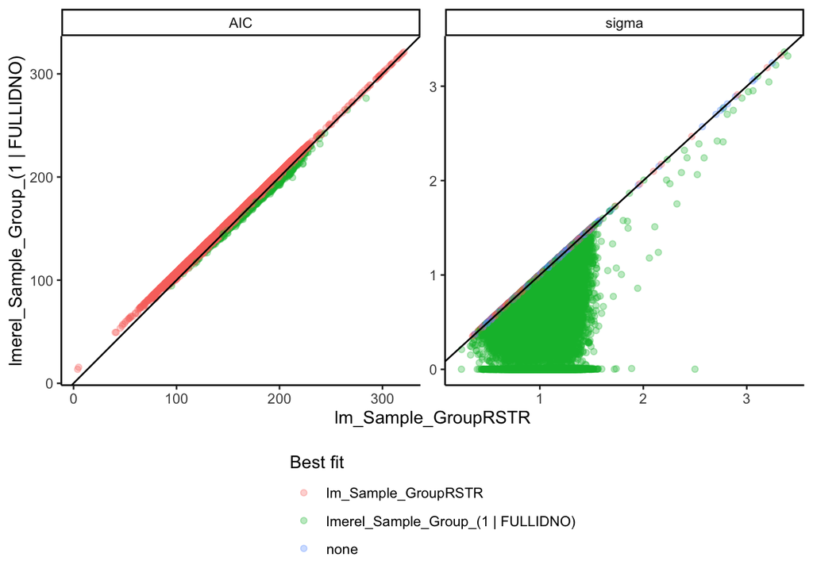

## Demographics: Age, sex, BMI

None of the metadata variables of interest differ between RSTR and LTBI groups. However, these variables may contribute to ATACseq profiles. Thus, additive models will be assessed in the kinship model subset. See `scripts/ATAC.models.R` for running of `kmFit` models

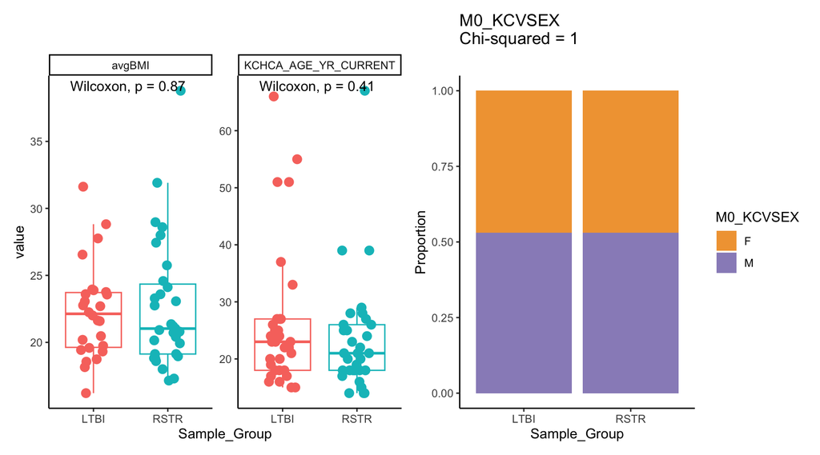

Here, we see a model with demographics improves model fit for the majority of of peaks with most of the signal coming from sex-associated peaks. Given these results and the model used for methylation, sex and age will be included in further analyses.

```
## Summary
```

```
##                                                                   Best fit
## 1                                       lmerel_Sample_Group_(1 | FULLIDNO)
## 2 lmerel_Sample_Group_KCHCA_AGE_YR_CURRENT_M0_KCVSEX_avgBMI_(1 | FULLIDNO)
##   Metric Total genes Mean delta Stdev delta
## 1    AIC        9315   4.195015    3.000517
## 2    AIC       33040   8.521461    5.703857
```

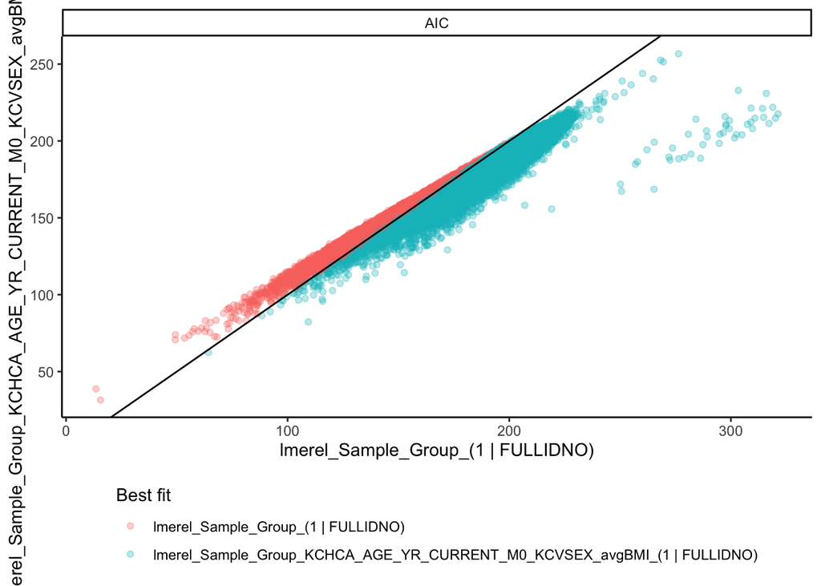

```
## # A tibble: 3 × 3
##   variable             fdr_0.05 fdr_0.2
##   <fct>                   <int>   <int>
## 1 M0_KCVSEX                  67     109
## 2 Sample_Group               NA       1
## 3 total (nonredundant)       67     110
```

## TB-related: Risk, BCG

Neither TB metadata variable of interest differs between RSTR and LTBI groups. However, these variables may contribute to ATACseq profiles. Thus, additive models will be assessed. See `scripts/ATAC.models.R` for running of `kmFit` models

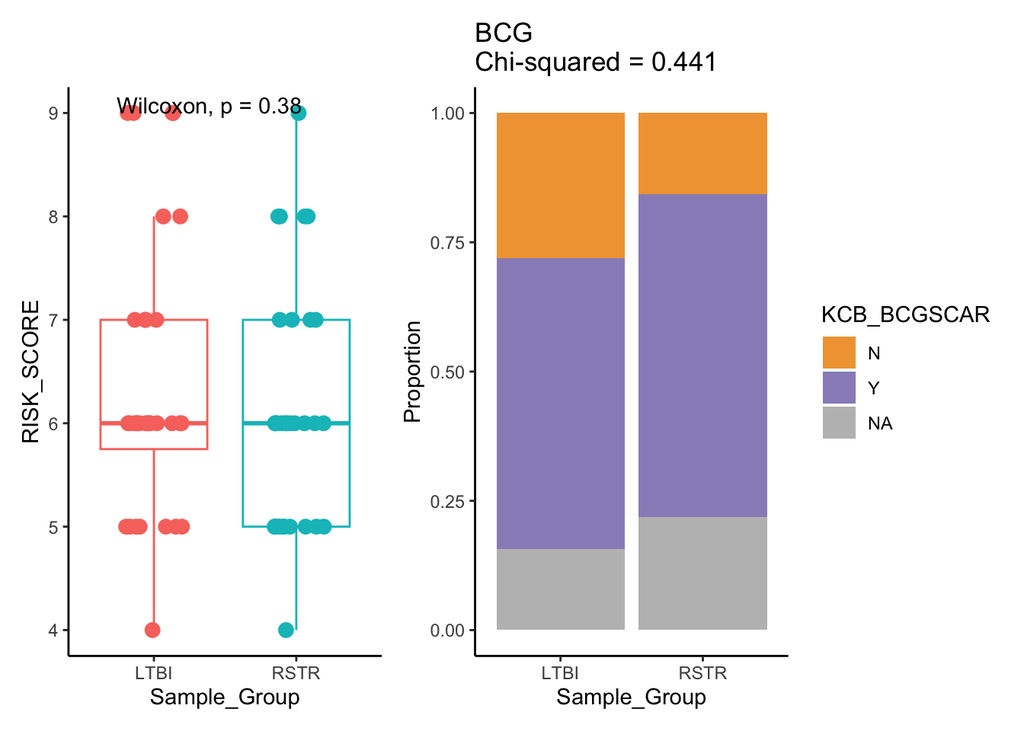

Here, we see that TB risk metrics improve model fit for the majority of genes. However, all of this signal still appears to come from the addition of sex. Given these results, the risk metrics will not be included in further analyses.

```
## Summary
```

```
##                                                                                   Best fit
## 1                                                       lmerel_Sample_Group_(1 | FULLIDNO)
## 2 lmerel_Sample_Group_KCHCA_AGE_YR_CURRENT_M0_KCVSEX_RISK_SCORE_KCB_BCGSCAR_(1 | FULLIDNO)
##   Metric Total genes Mean delta Stdev delta
## 1    AIC         478   3.633768    3.138377
## 2    AIC       41877  22.042151    8.518546
```

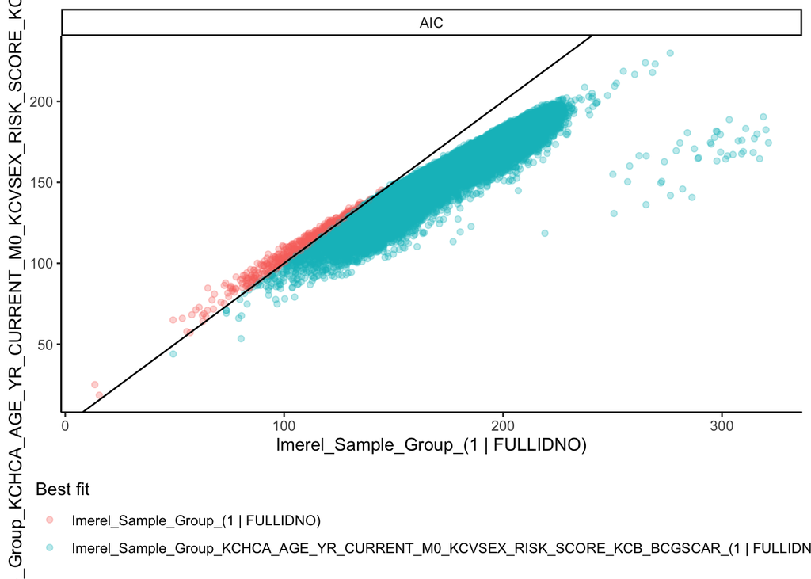

```
## # A tibble: 3 × 3
##   variable             fdr_0.05 fdr_0.2
##   <fct>                   <int>   <int>
## 1 KCB_BCGSCAR                NA       5
## 2 M0_KCVSEX                  93     153
## 3 total (nonredundant)       93     158
```

## Model summary

`~ Sample_Group + M0_KCVSEX + KCHCA_AGE_YR_CURRENT + (1|Sample), varlist=kin`

Excluded

```r
load("results/model_selection/kinship_final_model.RData")
```

```
## Summary
```

```
##                                                            Best fit Metric
## 1                                lmerel_Sample_Group_(1 | FULLIDNO)    AIC
## 2 lmerel_Sample_Group_KCHCA_AGE_YR_CURRENT_M0_KCVSEX_(1 | FULLIDNO)    AIC
##   Total genes Mean delta Stdev delta
## 1       42180   9.882521    2.096649
## 2         175  19.901152   30.520545
```

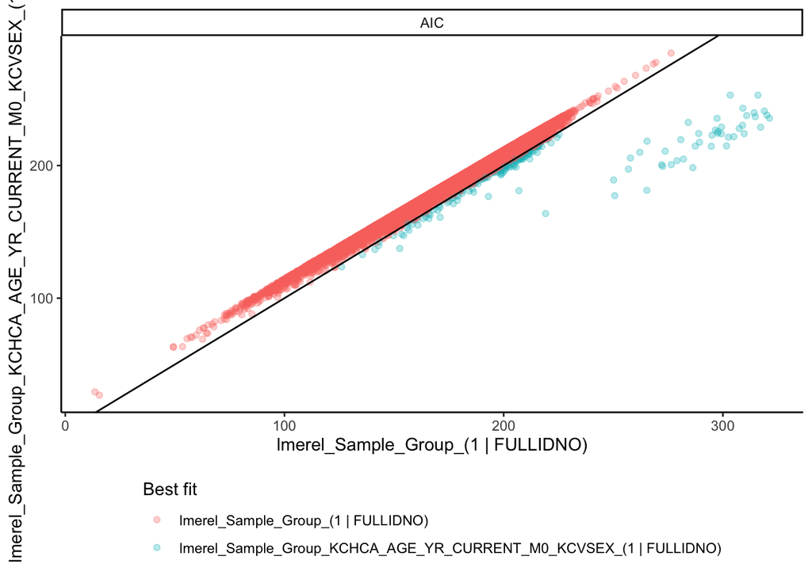

```
## # A tibble: 2 × 2
##   variable             fdr_0.3
##   <fct>                  <int>
## 1 Sample_Group               1
## 2 total (nonredundant)       1
```

```
## # A tibble: 4 × 3
##   variable             fdr_0.2 fdr_0.3
##   <fct>                  <int>   <int>
## 1 KCHCA_AGE_YR_CURRENT      22      78
## 2 M0_KCVSEX                100     123
## 3 Sample_Group               2       2
## 4 total (nonredundant)     124     202
```